# My background and possible connections with the Learning and Instruction Lab

rich-ramsey.github.io/talks/li-lab-25/

Richard Ramsey  
[www.rich-ramsey.com](https://rich-ramsey.com)

[figure not shown]

# Today

- Brief biography
- Past research interests
- Motivating context
- Data science
- Opportunities with the Learning and Instruction Lab

# Brief biography

## Life

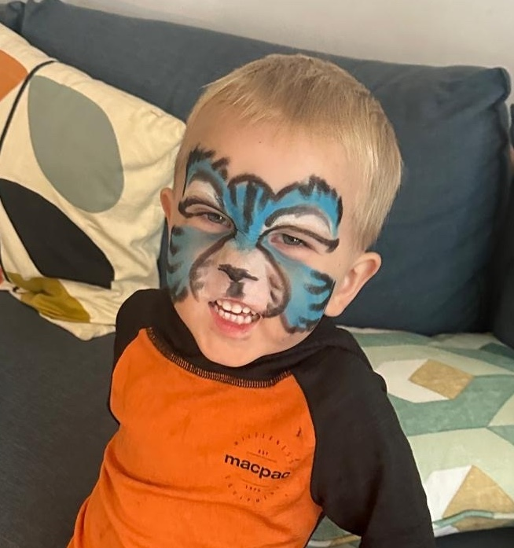

[figure not shown]

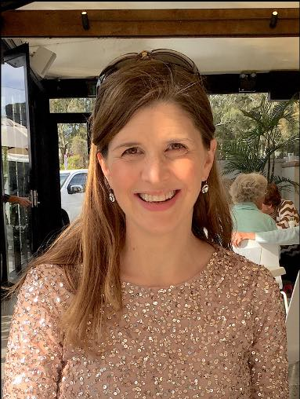

[figure not shown]

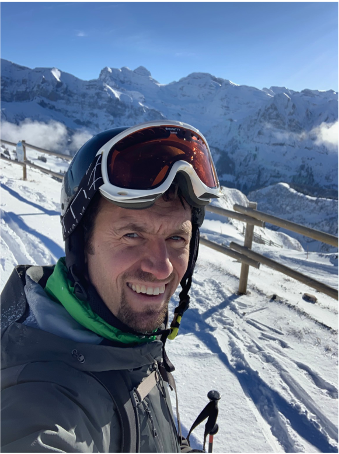

[figure not shown]

## Academic biography

| Position | Degree/Research Theme | Year | Place |
| --- | --- | --- | --- |
| BSc. | Sport & Exercise Science | 2001-2004 | Birmingham, UK |
| PhD | Sport Psychology & Cognitive Neuroscience | 2004-2008 | Birmingham, UK |
| Postdoc | Social & Cognitive Neuroscience | 2007-2011 | Nottingham, UK |
| Postdoc | Social & Cognitive Neuroscience | 2011 | UCL, Belgium |
| Lecturer, Senior Lecturer, Reader | Social & Cognitive Neuroscience | 2011-2019 | Bangor University, UK |
| Associate Professor | Social & Cognitive Neuroscience | 2020-2023 | Macquarie University, Australia |
| Senior Scientist | Social & Cognitive Neuroscience | 2023- | ETH Zurich |

## Relevant experience

- Balanced academic roles
  - research, teaching and leadership
- 10 PhD students to completion as PI
- 5 postdocs
- Grant funding
- Teaching (20+ years in higher education)
  - sport psychology, cognitive neuroscience, methods & meta-science
- Leadership
  - PhD committee chair

# Past research interests

## Past research interests

[figure not shown]

**Person perception**

[figure not shown]

**Imitation**

[figure not shown]

**Loneliness**

[figure not shown]

**Observational learning**

[figure not shown]

**Neuroaesthetics**

[figure not shown]

**Behaviour**

[figure not shown]

**fMRI**

[figure not shown]

**Metascience**

[figure not shown]

**Theoretical work**

[figure not shown]

**Computational modelling**

# Motivating context

## Wheel of death

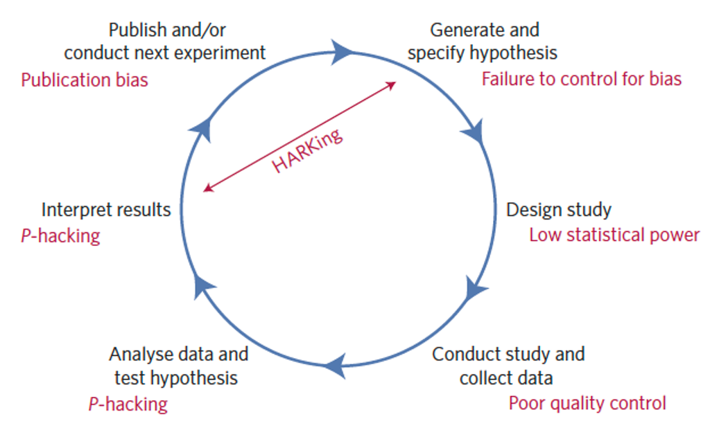

(Munafò et al. 2017)

## Towards a cumulative science?

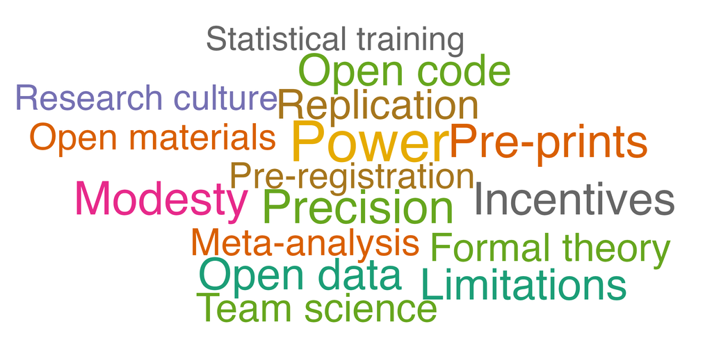

(Munafò et al. 2017; Ramsey 2020, 2021)

## Who does the following?

✋ = sometimes | ✋✋ = routinely

- Shares data
- Shares code
- Performs code review
- Shares materials
- Pre-registers experiments
- Uses version control (e.g., git)
- Consults a statistician
- Pre-prints papers
- Replicates their own work
- Uses formal theory

# Data science

## Data science

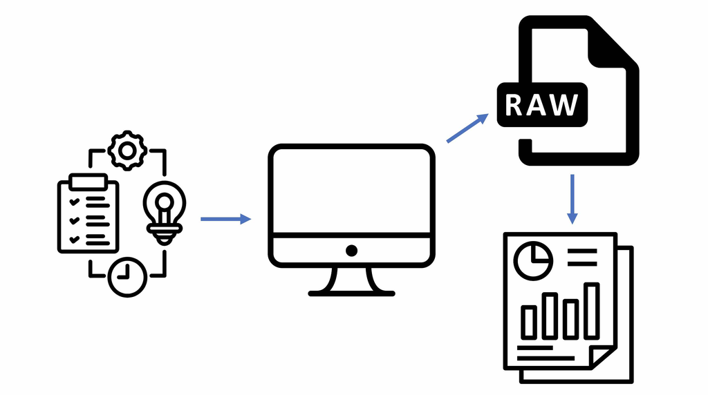

## R for Data science

- R for Data Science
- A free, online book: https://r4ds.hadley.nz/
- Or buy the hard copy
- This should be your data science bible

[figure not shown]

## Reproducible data science

[figure not shown]

- No Excel sheets !
- Instead:
- A raw data file (i.e., trial level data with no exclusions).
- An analysis script (or set of scripts)

## Openness

[figure not shown]

[figure not shown]

**Open Science Framework**

[figure not shown]

**GitHub**

[figure not shown]

**PsyArXiv**

## Rstats

[figure not shown]

[figure not shown]

[figure not shown]

## Reproducible scientific workflows

https://quarto.org/

A tutorial from my lab: https://github.com/rich-ramsey/reproducible_workflow_quarto

# Opportunities with the Learning and Instruction Lab

## Data science and Rstats

- Infrastructure and openness (mainly in R).
- Data wrangling and visualisation
- Bayesian multi-level regression models
- Planning studies via data simulation
- Git and version control
- Reproducible workflows via Quarto

## Learning

- Get me out of the lab and into the “real world” …
- How does plasticity in cognitive and brain mechanisms support learning?
- How do visuo-motor “training” interventions compare to learning interventions?
- Can questions and measures be motivated by cognitive neuroscience (e.g., group bias, observational learning etc.)?
- Can we kick-start a conversation about new projects?

# Acknowledgements

- Inez Greven
- Emily Butler
- Andrew Wildman
- Ionela Bara
- Chris Byrne
- Kohinoor Darda
- Dace Apšvalka
- Kohinoor Darda
- Raphaël Fournier
- Paul Downing
- Emily Cross
- Rudi Coetzer
- Eliane Deschrijver
- Rob Ward
- Richard Binney
- Dave Kaplan
- Sam Parker
- Sven Panis

[figure not shown]

[figure not shown]

[figure not shown]

[figure not shown]

## And here’s my stuff

- Slides: www.rich-ramsey.github.io/talks/li-lab-25/
- Code: https://github.com/rich-ramsey/talks
- Website: www.rich-ramsey.com
- Github: https://github.com/rich-ramsey

[figure not shown]

## References

Kruschke, John. 2014. *Doing Bayesian Data Analysis: A Tutorial with R, JAGS, and Stan*. Academic Press. https://books.google.com?id=FzvLAwAAQBAJ.

McElreath, Richard. 2020. *Statistical Rethinking: A Bayesian Course with Examples in R and Stan*. CRC press.

Munafò, Marcus R., Brian A. Nosek, Dorothy V. M. Bishop, Katherine S. Button, Christopher D. Chambers, Nathalie Percie du Sert, Uri Simonsohn, Eric-Jan Wagenmakers, Jennifer J. Ware, and John P. A. Ioannidis. 2017. “A Manifesto for Reproducible Science.” *Nature Human Behaviour* 1: 0021. https://doi.org/10.1038/s41562-016-0021.

Ramsey, Richard. 2020. “Advocating for the Credibility Revolution.” *Cognitive Psychology Bulletin* 5. https://doi.org/10.53841/bpscog.2020.1.5.70.

———. 2021. “A Call for Greater Modesty in Psychology and Cognitive Neuroscience.” *Collabra: Psychology* 7 (1): 24091. https://doi.org/10.1525/collabra.24091.

Winter, Bodo. 2019. *Statistics for Linguists: An Introduction Using R*. Routledge. https://books.google.com?id=8cbADwAAQBAJ.

## Resources

- Unless otherwise specified, icons were used under license from [The Noun Project](https://thenounproject.com/)
- Slides were created with [Quarto](https://quarto.org/) and [RevealJS](https://revealjs.com/)